# Gini Exercise

Simon Halliday

2016-June -20

## Intro

This is my attempt to reproduce Richard Ball’s Gini Index exercise with nothing other than the instructions.

## Setup

I used the following packages

```r
knitr::opts_chunk$set(echo = TRUE)
library(dplyr)
```

```r
library(ggplot2)
library(tidyr)
library(readr)
```

We need to import the data. I had to open the data with Stata and run the .do file provided by IPUMS to get the data into a sensible shape. I then exported the data to csv. using the `outsheet` command.

Below, I use `read_cvs` from the `readr` package to import the pretty large (~400mb) csv file

```r
CPS <- read_csv("/Users/shalliday/Google Drive/simondhalliday.github.io/conferences/tier_workshop/cps.csv")
```

## Generating variables

We only want household (HH) data, so I simply filter on the person codes so that I keep the first person in each HH. I also generate the real household income and real HH per capita incomes in the code below.

```r
CPShh <-
  CPS %>%
  filter(pernum == 1) %>%
  mutate(realhhy = hhincome*cpi99,
         realpcy = realhhy/numprec)
```

I next generate the two rank and covariance vectors by year. To do this, I use `group_by` from `dplyr`.

```r
CPShh2 <-
  CPShh %>%
  group_by(year)%>%
  mutate(pcyrank = rank(realpcy, ties.method = c("random")),
         hhyrank = rank(realhhy, ties.method = c("random")))
CPShh2 <-
  CPShh2 %>%
  arrange(pcyrank) %>%
  mutate(covpcyrank = cov(realpcy, pcyrank))
CPShh3 <-
  CPShh2 %>%
  arrange(hhyrank) %>%
  mutate(covhhyrank = cov(realhhy, hhyrank))
```

I think some of the code above may be redundant, but such is life.

To compute the Gini index, we need the mean household incomes, mean per capita incomes, total population of households.

```r
CPShhy <-
  CPShh %>%
  group_by(year) %>%
  summarise(meanhhy = mean(realhhy),
            medhhy = median(realhhy),
            meanpcy = mean(realpcy),
            medpcy = median(realpcy),
            totalhh = n())
```

I now need to re-merge the data such that everyone in a given year has that year’s aggregate attributes.

Start with the per-capita data.

```r
CPShh4 <-
  CPShh2 %>%
  left_join(CPShhy) %>%
  mutate(pcgini = (2*covpcyrank)/(totalhh*meanpcy))
head(CPShh4)
```

```
## Source: local data frame [6 x 22]
## Groups: year [1]
##
##    year serial numprec hwtsupp asecflag hflag hhincome cpi99 month pernum
##   (int)  (int)   (int)   (dbl)    (chr) (chr)    (int) (dbl) (chr)  (int)
## 1  1980  52878       1 2311.08     ASEC    NA    -9999 2.295 March      1
## 2  1980  42393       2 1360.89     ASEC    NA   -19998 2.295 March      1
## 3  1980  53977       2  752.82     ASEC    NA   -18109 2.295 March      1
## 4  1980  56442       1 1489.23     ASEC    NA    -6999 2.295 March      1
## 5  1980  31475       1  204.93     ASEC    NA    -6705 2.295 March      1
## 6  1980  34170       1  623.15     ASEC    NA    -6256 2.295 March      1
## Variables not shown: wtsupp (dbl), realhhy (dbl), realpcy (dbl), pcyrank
##   (int), hhyrank (int), covpcyrank (dbl), meanhhy (dbl), medhhy (dbl),
##   meanpcy (dbl), medpcy (dbl), totalhh (int), pcgini (dbl)
```

Now the HH data:

```r
CPShh5 <-
  CPShh3 %>%
  left_join(CPShhy) %>%
  mutate(hhgini = (2*covhhyrank)/(totalhh*meanhhy))
head(CPShh5)
```

```
## Source: local data frame [6 x 23]
## Groups: year [1]
##
##    year serial numprec hwtsupp asecflag hflag hhincome cpi99 month pernum
##   (int)  (int)   (int)   (dbl)    (chr) (chr)    (int) (dbl) (chr)  (int)
## 1  1980  46333       4 1558.83     ASEC    NA   -19998 2.295 March      1
## 2  1980  42393       2 1360.89     ASEC    NA   -19998 2.295 March      1
## 3  1980  61138       5  271.40     ASEC    NA   -19397 2.295 March      1
## 4  1980  18546       6 1582.15     ASEC    NA   -18898 2.295 March      1
## 5  1980  53977       2  752.82     ASEC    NA   -18109 2.295 March      1
## 6  1980  71943       4   65.61     ASEC    NA   -10744 2.295 March      1
## Variables not shown: wtsupp (dbl), realhhy (dbl), realpcy (dbl), pcyrank
##   (int), hhyrank (int), covpcyrank (dbl), covhhyrank (dbl), meanhhy (dbl),
##   medhhy (dbl), meanpcy (dbl), medpcy (dbl), totalhh (int), hhgini (dbl)
```

We now need to summarize this down to a year-specific variable. Because the number is a scalar and identical within year, the mean will be identical to each observation.

For per-capita:

```r
CPSpcGini <-
  CPShh4 %>%
  group_by(year) %>%
  summarise(pcgini = mean(pcgini))
```

For HH:

```r
CPShhGini <-
  CPShh5 %>%
  group_by(year) %>%
  summarise(hhgini = mean(hhgini))
head(CPShhGini)
```

```
## Source: local data frame [6 x 2]
##
##    year    hhgini
##   (int)     (dbl)
## 1  1980 0.3945666
## 2  1981 0.3953913
## 3  1982 0.4039958
## 4  1983 0.4093514
## 5  1984 0.4103134
## 6  1985 0.4151021
```

## Plots

To generate the plots, I need to `gather` the data (make it narrow) to have the relevant variable (income) in one column, with two different `types` of measure (median and mean) and I’ll do the same for HH and per-capita:

```r
CPShhyTemp <-
  CPShhy %>%
  select(year, meanhhy, medhhy)
HHyplotdata <-
  CPShhyTemp %>%
  gather(type, hhincome, meanhhy:medhhy)
head(HHyplotdata)
```

```
## Source: local data frame [6 x 3]
##
##    year    type hhincome
##   (int)   (chr)    (dbl)
## 1  1980 meanhhy 43636.92
## 2  1981 meanhhy 41348.86
## 3  1982 meanhhy 41093.06
## 4  1983 meanhhy 41022.13
## 5  1984 meanhhy 41651.66
## 6  1985 meanhhy 43582.11
```

Household income plot

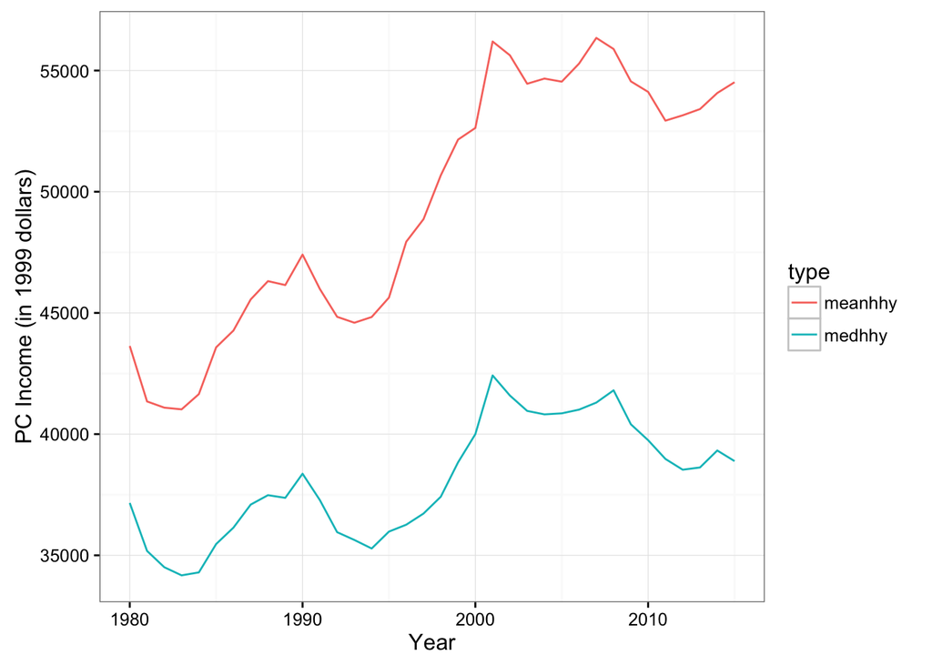

```r
HHyplotdata %>%
  ggplot(aes(x = year, y = hhincome, group = factor(type))) +
  geom_line(aes(color = type)) +
  xlab("Year") +
  ylab("PC Income (in 1999 dollars)") +
  theme_bw()
```

Household Gini plot

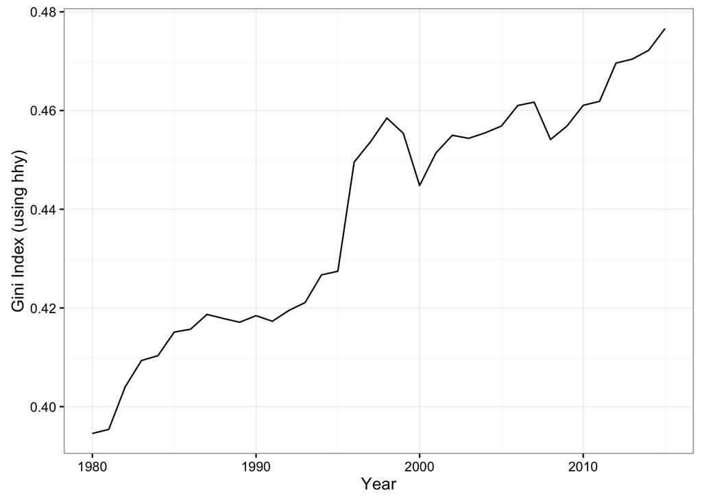

```r
CPShhGini %>%
  ggplot(aes(x = year, y = hhgini)) +
  geom_line() +
  xlab("Year") +
  ylab("Gini Index (using hhy)") +
  theme_bw()
```

Per capita income generation

```r
CPShhpcyTemp <-
  CPShhy %>%
  select(year, meanpcy, medpcy)
HHpcyplotdata <-
  CPShhpcyTemp %>%
  gather(type, pcy, meanpcy:medpcy)
head(HHpcyplotdata)
```

```
## Source: local data frame [6 x 3]
##
##    year    type      pcy
##   (int)   (chr)    (dbl)
## 1  1980 meanpcy 18108.14
## 2  1981 meanpcy 17407.28
## 3  1982 meanpcy 17478.31
## 4  1983 meanpcy 17476.10
## 5  1984 meanpcy 17920.52
## 6  1985 meanpcy 18843.97
```

Per-capita income plot

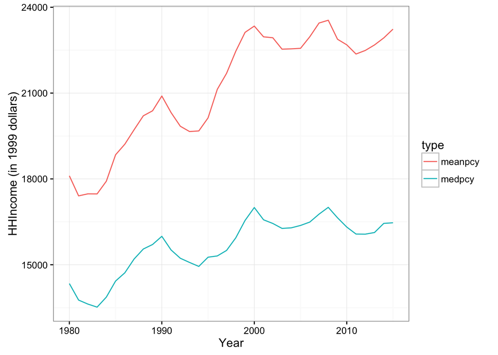

```r
HHpcyplotdata %>%
  ggplot(aes(x = year, y = pcy, group = factor(type))) +
  geom_line(aes(color = type)) +
  xlab("Year") +
  ylab("HHIncome (in 1999 dollars)") +
  theme_bw()
```

Per-capita Gini plot

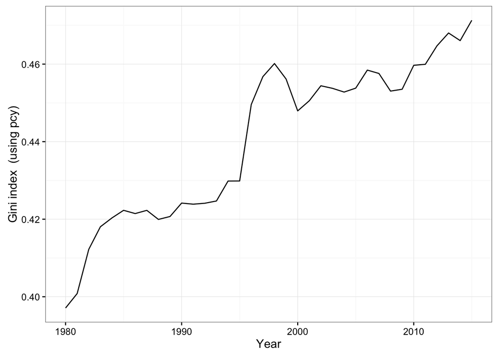

```r
CPSpcGini %>%
  ggplot(aes(x = year, y = pcgini)) +
  geom_line() +
  xlab("Year") +
  ylab("Gini index  (using pcy)") +
  theme_bw()
```